# Non-Exchangeable Priors for Bayesian Nonparametric Models

2025-11-11

## Introduction

Suppose you are working with an infinite mixture model. You will need a prior on the mixture probabilities, such as a Dirichlet process.

Suppose you have covariate data that should probably inform how the data is partitioned. But none of the standard mixture priors allow for dependence.

What dependent methods are available and how do you pick the right one? The authors Nicholas Foti, Sinead Williamson, et al have some ideas.

## Outline

- Exchangeability vs Dependence
- Construction of an NP prior in 3 stages
- Traditional non-parametric priors: Dirichlet Process, Chinese Restaurant Process, Pitman-Yor Process, Indian Buffet
- How dependence can be added in any of the three stages
- What type of dependence is captured by each approach
- Considerations in selecting an approach
- Conclusions

## Exchangeable vs Non-Exchangeable

Priors constructed by Bayesian nonparametric processes generally assume that your data is exchangeable. That is, the joint distribution of the data is symmetric for any finite permutation of the indices.

But we frequently work with spatial or temporal data, which is non-exchangeable!

- Observing \((X_1=0,X_2=3,X_3=8)\) is different from observing \((X_1=8,X_2=0,X_3=3)\)

## Design of NP Prior: De Finetti’s Theorem

De Finetti’s Theorem: Any infinite exchangeable sequence \(Y_1, Y_2,\dots\) can be expressed as a mixture of iid samples where \(Q_{\theta}\) is a family of conditional distributions and \(P\) is a distribution over \(\Theta\) called the de Finetti mixing measure.

\[\mathbb{P}(Y_1,Y_2,\dots, Y_n)= \int \prod_{i=1}^n Q_{\theta}(Y_i) P(d\theta)\]

## Design of NP Prior: De Finetti’s Theorem

- Construction of a distribution over countably infinite measures over \(\Theta\) (the de Finetti mixing measure).
- Choice of the conditional distribution family \(Q_{\theta}\) (the observation generating mechanism).
- Integrate out the De Finetti measure and work directly with the predictive distributions \(p(Y_{n+1} | Y_1 \dots Y_n)\).

Each of these steps provide opportunities for injecting dependence.

## De Finetti Mixing Measure

The de Finetti measure is a discrete measure characterized by the size and location of its atoms. Usually, it can be described by a mechanism \(f\) for generating a countable number of atom sizes and an independent mechanism \(g\) for generating corresponding locations. Then a measure \(G\) is generated as

\[\Pi := \pi_1, \pi_2, … \sim f\] \[\theta_k \sim^{iid} g\]  
\[G=\sum_{k=1}^{\infty} \pi_k \delta_{\theta_k}\]

## Stick Breaking Construction

A common choice for \(f\) is the stick breaking construction.

\[\pi_k = V_k \prod_{j=1}^{k-1}(1-V_j)\] \[V_k\sim \text{Beta}(a_k,b_k)\]

Proper choices of \(a_k\) and \(b_k\) can represent the Dirichlet process \((a_k=1,b_k=\alpha)\) and the Pitman-Yor process \((a_k=1-a, b_k=b+ka)\).

## OGM and Predictive Distribution

Once we have chosen a de Finetti mixing measure, we select a family of conditional likelihoods to describe the distribution of \(Y|\theta\). This family is generally chosen to be conjugate to the de Finetti measure.

- Given a Dirichlet process, we can choose a multinomial distribution to get a distribution over exchangeable clusterings or partitions.
- Given a gamma process, we can choose a Poisson distribution to get a distribution over exchangeable sequences of integers.

If we have conjugacy between the de Finetti measure and the observation generating mechanism, then we can generally obtain the predictive distribution \(p(Y_i|Y_1,\dots,Y_{i-1})\) analytically.

## Traditional Nonparametric Priors

- Dirichlet Process: realizations are discrete probability distributions.
- Chinese Restaurant Process: realizations are random partitions over data.
- Indian Buffet Process: realizations are sparse binary matrices with finite rows and infinite columns
- Pitman-Yor Process: realizations are probability distributions. An additional parameter gives more flexibility over the tail behavior.

## Method 1: Dependence in Atom Sizes

The first category of approaches is to generate the atom sizes from a covariate dependent distribution.

\[\Pi= \pi_1,\pi_2,\dots \sim f|X\]

This approach allows you to model situations where the proportions of the latent variables vary across the covariate space.

## Method 1: Graphical Representation

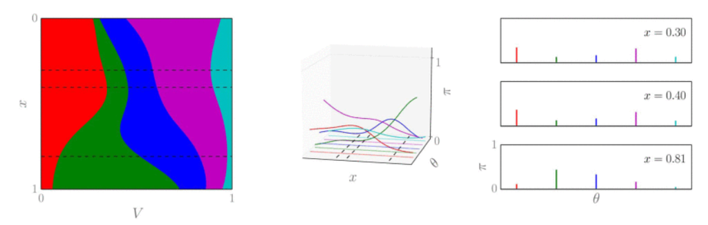

Here, \(\theta\) stays the same for different covariate values while \(\pi\) changes.

## Method 1: Kernel Stick-Breaking Process

The kernel stick-breaking process, devised by D. B. Bunson and J. H. Park, modifies the regular stick-breaking process with a kernel function \(K:\mathbb{X}\times \mathbb{X}\to [0,1]\) to define

\[\pi_k^{(x)}=V_kK(x,\mu_k)\prod_{j=1}^{k-1}(1-V_j)K(x,\mu_j)\]

where \(V_k\sim \text{Beta}(a_k,b_k)\) and \(\mu_k\in \mathbb{X}\) are random covariate locations for the sticks.

While the resulting process is no longer marginally Dirichlet, it is not hard to perform inference through MCMC or variational inference.

## Method 2: Dependence in Atom Locations

The second approach is to generate the atom locations from a covariate dependent distribution.

\[\theta_k \sim^{iid} g|X\]

This allows us to model situations where the values of some parameters are expected to change with the covariates.

## Method 2: Graphical Representation

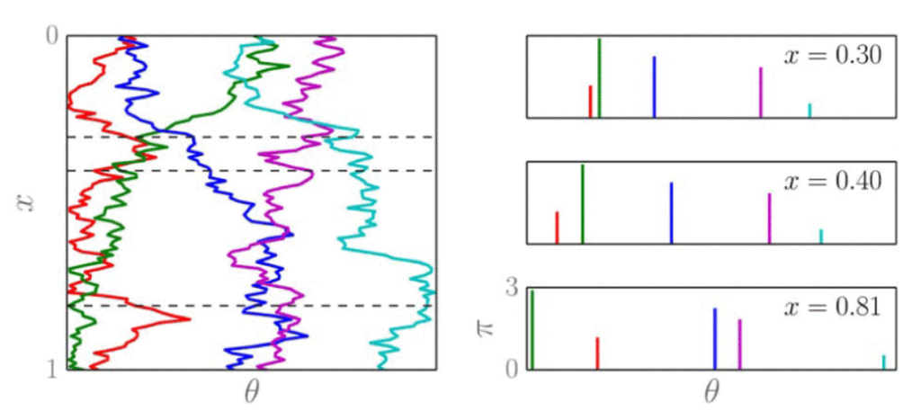

## Method 2: Spatial Dirichlet Process

One example of this is the spatial Dirichlet process proposed by Gelfand et al. They use a Dirichlet process to simulate the atom sizes and treat each location \(\theta_k\) as a realization of a random field. For example, the base measure of the DP could be a stationary Gaussian process and the \(\theta_{k,D}\) would be realizations of the GP over a set of covariate locations \(D\). Each replicate set of observations over \(D\) is considered to have come from a distinct random field.

\[\Pi:= (\pi_1,\pi_2,\dots) \sim \text{Stick}(1,\alpha),\text{ } \theta_{k,D}\sim GP(0,V)\]

The resulting random stochastic process is non-stationary and non-Gaussian, allowing the Spatial Dirichlet Process to accommodate subtler relationships with its covariate information.

## Method 3: Dependence in the OGM

We can also introduce dependence through the observation generating mechanism \(Q_\theta\). Recall that this is a conditional distribution of our observations \(Y\) parameterized by a finite vector \(\theta\) generated by the de Finetti mixing measure.

Many methods in this category utilize smooth latent surfaces to select mixture components, which enforces a locally similar clustering structure.

## Method 3: Generalized Spatial DP

The generalized spatial DP by Gelfand et al. extends the spatial DP so that a single observation of all locations can be represented by different surfaces at different locations. Given \(\Pi:= (\pi_1,\pi_2,\dots) \sim \text{Stick}(1,\alpha)\), we draw a set of correlated samples \((Z_n^{(x)}: x\in \mathbb{X})\) and select a field for each location \(x\in \mathbb{X}\).

Let \(Z_i, i=1,2,\dots\) be independent Gaussian random fields with unit variance and mean functions \(m_i(\cdot)\) such that

\[\Phi(m_i(x))\sim^{iid} \text{Beta}(1,\alpha)\]

Then for each \(x\in\mathbb{X}\), we define \(Z_n(x)=\max Z_i(x)\) and \(Y_n(x)=\theta_{Z_n(x)}(x)\).

## Method 4: Dependence in the Predictive Distribution

Lastly, we can add dependence by manipulating the predictive distribution \(p(X_{n+1}|X_1,\dots, X_n)\). This allows us to model situations where we expect observations to be similar to observations at nearby covariates. There are two general approaches here.

- Given a sequence of observations that arrive over time in batches, create Markov chains of CRPs that incorporate a subset of observations from the previous time into the current CRP. (GPU-DDP by Caron, Davy, and Doucet)
- Modify the predictive distribution directly to depend on a covariate or function thereof.

## Method 4: Distance-Dependent CRP

An example of the second approach is the Distance Dependent Chinese Restaurant Process described by Blei and Frazier. This method defines a dissimilarity measure between observations \(i\) and \(j\) denoted as \(d_{ij}\) and a decay function \(f(\cdot)\) that is monotonically decreasing. Each new point is assigned to a previous point, or to itself, with probability

\[p(c_i=j|D,\alpha) \propto\begin{cases} f(d_{ij})\text{ if }i\neq j\\ \alpha \text{ if } i=j \end{cases}\]

## Choosing a Dependent Process

The first consideration is what kind of dependence you are trying to capture.

- If the values of some parameters are expected to change with a covariate, then the locations of the de Finetti mixture measure can be made dependent while its weights are held constant.
- If you expect the proportions of the latent components to vary across the covariate space, then holding the locations fixed while the weights are made dependent is appropriate.
- If you expect that observations will be similar to observations at nearby covariates, then introducing dependence through the marginal distributions or the predictive distributions is the best way to accomplish this.

## Other Considerations

- What is the nature of your covariate space? In particular, is it ordered such as with time?
- Is there prior information about the form of the marginal distributions?
- Is your primary goal prediction, or inference on parameters, or identification of trends?

## Conclusions

The field of dependent nonparametric processes remains highly active and more methods have likely been developed since its publication.

This paper was quite helpful in my own research and I hope it will be in yours as well.

## References

N. J. Foti and S. A. Williamson, “A Survey of Non-Exchangeable Priors for Bayesian Nonparametric Models,” in IEEE Transactions on Pattern Analysis and Machine Intelligence, vol. 37, no. 2, pp. 359-371, Feb. 2015 https://ieeexplore.ieee.org/document/6654119

D. B. Dunson and J.-H. Park, “Kernel stick-breaking processes,” Biometrika, vol. 95, no. 2, pp. 307–323, 2008. https://pmc.ncbi.nlm.nih.gov/articles/PMC2538628

A. E. Gelfand, A. Kottas, and S. N. MacEachern, “Bayesian nonparametric spatial modelling with Dirichlet process mixing,” J. Amer. Statist. Assoc., vol. 100, no. 471, pp. 1021–1035, 2005.

A. Duan, M. Guindani, and A. E. Gelfand, “Generalized spatial Dirichlet process models,” Biometrika, vol. 94, no. 4, pp. 809–825, 2007.

D. M. Blei and P. I. Frazier, “Distance dependent Chinese restaurant processes,” J. Mach. Learn. Res., vol. 12, pp. 2461–2488, Aug. 2011.